# Predicting Excessive Enforcement Patterns in Police Behavior After Vehicles Stops in New York

### Reported Sex

```r
ratio_by_cat(
  vehstops, arrested, sex,
  "Reported sex", "Arrest Rate (%)", "Arrest Ratio by Reported sex for Cars Stopped in NYC",
  style = "stack", legend_title = "Stop ended in arrest?", target_labels = c("No", "Yes"),
  subtitle = "Male drivers are subject to higher arrest rates, followed by Unknown category",
)
```

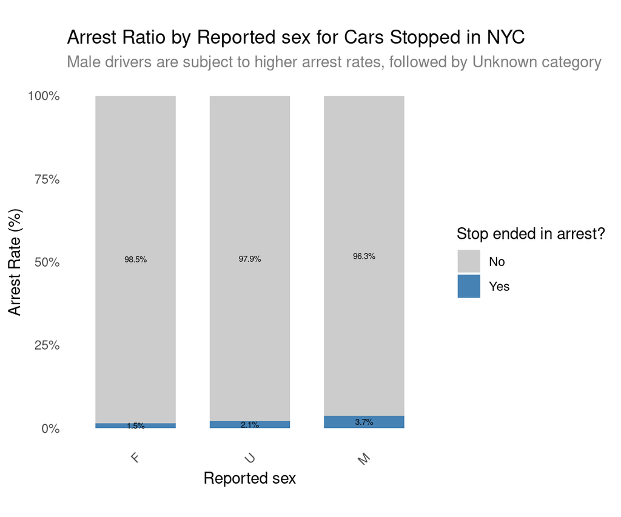

```r
vehstops %>%
  group_by(sex, arrested) %>%
  summarise(count = n(), .groups = "drop_last") %>%
  mutate(percentage = count / sum(count))
```

```
## # A tibble: 6 × 4
## # Groups:   sex [3]
##   sex   arrested   count percentage
##   <chr>    <int>   <int>      <dbl>
## 1 F            0  389381     0.985
## 2 F            1    5966     0.0151
## 3 M            0 1672515     0.963
## 4 M            1   64333     0.0370
## 5 U            0   13116     0.979
## 6 U            1     276     0.0206
```

What can we say?

- **Key finding**: This highlights a clear disparity in arrest rates across reported sex categories for 4-wheeled vehicle stops. Female drivers (`F`) experience the lowest arrest rate at $1.51\%$ ($5966$ arrests), followed by the unknown or unrecorded category (`U`) at $2.06\%$ (with $276$ arrests). Male drivers (`M`) are subject to the highest rate, with $3.70\%$ of their total stops resulting in an arrest ($64,333$).
- **Interpretation**: The ratio of arrest, given a stop, **is more than twice as high for male drivers compared to female** drivers. This variation affects our analysis by showing that there is a consistent and proportional gap between the 2 analyses. This confirms that reported sex remains a key predictor that needs to be included in our statistical models.
- **Comment**: The relative arrest rates are generally lower across all categories for cars than for 2-wheeled vehicles (e.g., $3.70\%$ vs $5.7\%$ for males).
- **Proposed Action**: Same as 2-wheels analysis.